```python
# # Run this code to appreciate the protagonist's eccentric preference and insistence on this hifalutin font

# from IPython.core.display import HTML

# HTML("""
# <style>
#     @import url('https://fonts.googleapis.com/css?family=Montserrat&display=swap');
#     body {
#         font-family: 'Montserrat', Courier New;
#     }
# </style>
# """)
```

# Uncovering Patterns in Crime Incidents in Washington DC :

# An Exploratory Data Analysis

### Analyzing Crime Trends from 2008-2017

#### Project by : Justin Ho Tze-Wei

#### Group : 8

#### Date : 25 Apr 2023

### INTRODUCTION

Washington DC is a vibrant city with a diverse population, but it also faces significant challenges with crime.

In this report, we analyze a dataset of crimes reported to the DC Metropolitan Police Department from 2008 to 2017 to gain insights into crime trends and patterns in the city. We examine three hypotheses related to the temporal, spatial, and seasonal aspects of crime incidents.

By exploring and visualizing the data, we aim to provide valuable insights to law enforcement agencies, policymakers, and the general public, to enhance their understanding of crime patterns in Washington DC.

### CONTENTS

Section 1 : Defining Hypotheses

Section 2 : Data Preparation

Section 3 : Data Exploration & Augmentation for Charts and Plots

Section 4 : Conclusion

Appendix : Image Gallery

### Section 1 : Defining Hypotheses

**Hypothesis 1** - There is a difference in the distribution of crime types between months, with violent crimes more likely to occur during certain months of the year compared to non-violent crimes.  
**Hypothesis 2** - Neighborhoods with a higher population density will have a higher frequency of reported crimes.  
**Hypothesis 3** - Crimes that occur during the night shift are more likely to involve violent offenses compared to crimes that occur during the day shift.

### Section 2 : Data Preparation

1. Import libraries
2. Read dataset
3. General string cleaning for data consistency and text readibility.
4. Removal of unwanted columns and data wrangling for missing values.
5. Prepping a clean copy of the dataframe for further augmentation for all plots and charts.

```python
import pandas as pd
import numpy as np
import calendar
import seaborn as sns
import matplotlib.pyplot as plt

%matplotlib notebook

# Show all columns in dataframe
pd.set_option('display.max_columns', None)

# Read dataset csv file
df = pd.read_csv('Datasets/Sociology/crime/dc_crime_add_vars.csv', encoding = 'unicode_escape')

# Change column names to uppercase
df.columns = df.columns.str.upper()

# String cleaning.  Rename columns.  Dropping unecessary column.  Set index.
df = df.rename(columns = {'REPORT_DAT': 'REPORT_DATE', 'X' : 'NO.'})
df.drop(['UNNAMED: 0'], axis = 1, inplace = True)
df = df.set_index('NO.')

# Show columns with summation of missing values
df.isnull().sum()

# View and check column/s showing missing values
# df[df['VOTING_PRECINCT'].isnull()]

# Fillna values of column that consist of census values with the mean
df['CENSUS_TRACT'].fillna(np.mean(df['CENSUS_TRACT']), inplace = True)
```

For both scenarios, be it dropping missing values or leaving the data intact, it does not result in a vast disparity of trend shifting for all charts and plots.

```python
# Drop missing values for rest of dataframe
df.dropna(inplace = True)

# For visual reference
df.head(2)
```

| NO. | REPORT_DATE | SHIFT | OFFENSE | METHOD | BLOCK | DISTRICT | PSA | WARD | ANC | NEIGHBORHOOD_CLUSTER | BLOCK_GROUP | CENSUS_TRACT | VOTING_PRECINCT | CCN | START_DATE | END_DATE | XBLOCK | YBLOCK | OPTIONAL | DATE | YEAR | MONTH | DAY | HOUR | MINUTE | SECOND | EW | NS | QUAD | … |
| --- | --- | --- | --- | --- | --- | --- | --- | --- | --- | --- | --- | --- | --- | --- | --- | --- | --- | --- | --- | --- | --- | --- | --- | --- | --- | --- | --- | --- | --- | --- |
| 1 | 8/31/2008 8:47:00 PM | EVENING | THEFT/OTHER | OTHERS | 3500 - 3599 BLOCK OF R STREET NW | 2.0 | 206.0 | 2 | 2E | Cluster 4 | 000300 1 | 300.0 | Precinct 6 | 8123749 | 8/30/2008 9:30:00 PM | 8/31/2008 6:40:00 PM | -77.070209 | 38.913633 | True | 2008-08-31 20:47:00 | 2008 | 8 | 31 | 20 | 47 | 0 | West | North | Northwest | … |
| 2 | 9/1/2008 12:45:00 AM | MIDNIGHT | MOTOR VEHICLE THEFT | OTHERS | 2000 - 2015 BLOCK OF O STREET NW | 2.0 | 208.0 | 2 | 2B | Cluster 6 | 005500 5 | 5500.0 | Precinct 14 | 8123824 | 8/31/2008 7:30:00 PM | 8/31/2008 11:30:00 PM | -77.045323 | 38.908564 | True | 2008-09-01 00:45:00 | 2008 | 9 | 1 | 0 | 45 | 0 | West | North | Northwest | … |

### Section 3 : Data Exploration & Augmentation for Charts and Plots

A presentation of charts and plots for the hypotheses, followed by their respective conclusions.

#### Trend overview by crime types per year

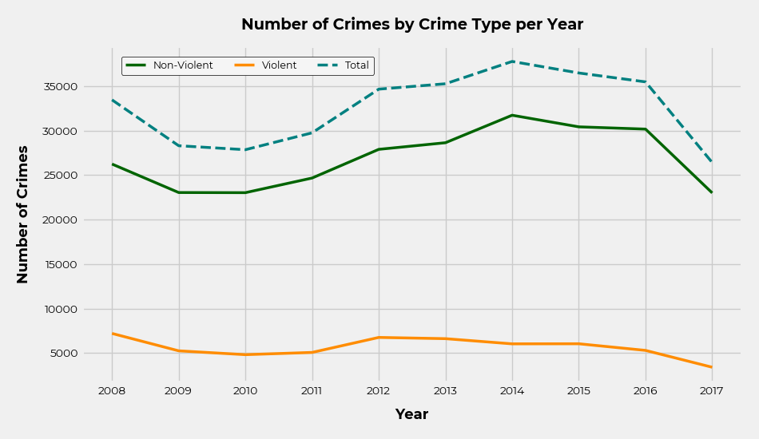

```python
# Set style parameters
plt.style.use('fivethirtyeight')
plt.rcParams['font.family'] = 'montserrat'

# Make a df copy
df1 = df.copy()

# Group selected data. Count number of crimes in each group
month_crime = df1[['YEAR', 'CRIMETYPE']]
grouped = month_crime.groupby(['YEAR', 'CRIMETYPE']).size().reset_index(name = 'counts')

# Pivot data so crimetype become column s
pivoted = grouped.pivot(index = 'YEAR', columns = 'CRIMETYPE', values = 'counts')

# Add column for total number of crimes per year
pivoted['Total'] = pivoted.sum(axis = 1)

# Plot chart
ax = pivoted.plot(kind = 'line', figsize = (9.5, 5.5), color = ['#006400', '#ff8c00', '#008080'])
ax.set_title('Number of Crimes by Crime Type per Year', fontsize = 14, fontweight = 'bold', pad = 15)
ax.set_xlabel('Year', fontsize = 13, fontweight = 'bold', labelpad = 10)
ax.set_ylabel('Number of Crimes', fontsize = 13, fontweight = 'bold', labelpad = 10)
ax.grid(True)

# Customize x-axis tick labels to display years
plt.xticks(pivoted.index)

# Adjust label size
ax.tick_params(axis = 'x', labelsize = 10)
ax.tick_params(axis = 'y', labelsize = 10)

# Place x-axis labels horizontally
plt.xticks(rotation = 0)

# Change linestyle of 'Total' line to dashed
lines = ax.get_lines()
lines[2].set_linestyle("--")

# Set line width for all lines
[line.set_linewidth(2.5) for line in ax.lines]

# Create legend for all lines
legend = ax.legend(fontsize = 9, frameon = True, edgecolor = 'black', bbox_to_anchor = (0.45, 0.9), ncol = 3)
legend.get_frame().set_linewidth(0.5)
legend.get_frame().set_facecolor('#F5F5F5')
legend.get_frame().set_alpha(1.0)

plt.tight_layout()
plt.show()
```

### Hypothesis 1

There is a difference in the distribution of crime types between months, with violent crimes more likely to occur during certain months of the year compared to non-violent crimes.

#### Line chart that shows the number of crimes by crime type per month

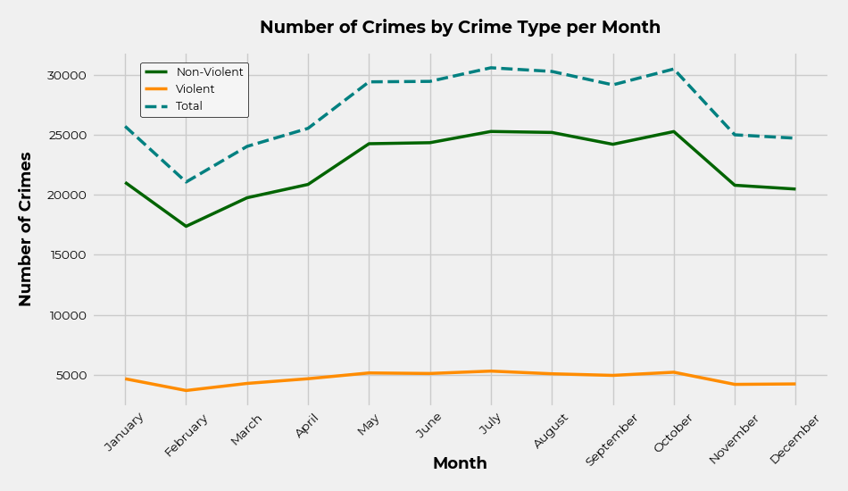

```python
# Filter and group data.  Count number of crimes in each group
month_crime = df1[['MONTH', 'CRIMETYPE']]
grouped = month_crime.groupby(['MONTH', 'CRIMETYPE']).size().reset_index(name = 'counts')

# Pivot data so crimetype become columns
pivoted = grouped.pivot(index = 'MONTH', columns = 'CRIMETYPE', values = 'counts')

# Add column for total number of crimes per month
pivoted['Total'] = pivoted.sum(axis = 1)

# Sort data by month
pivoted.sort_index(inplace = True)

# Plot chart
ax = pivoted.plot(kind = 'line', figsize = (9.5, 5.5), color = ['#006400', '#ff8c00', '#008080'])
ax.set_title('Number of Crimes by Crime Type per Month', fontsize = 14, fontweight = 'bold', pad = 15)
ax.set_xlabel('Month', fontsize = 13, fontweight = 'bold', labelpad = -10)
ax.set_ylabel('Number of Crimes', fontsize = 13, fontweight = 'bold', labelpad = 10)
ax.grid(True)

# Adjust label size
ax.tick_params(axis = 'x', labelsize = 10)
ax.tick_params(axis = 'y', labelsize = 10)

# Customize x-axis tick labels to display months
months = [calendar.month_name[i] for i in range(1, 13)]
plt.xticks(range(1, 13), months)

# Rotate x-axis labels by 45 degrees
plt.xticks(rotation = 45)

# Change linestyle of 'Total' line to dashed
lines = ax.get_lines()
lines[2].set_linestyle("--")

# Set line width for all lines
[line.set_linewidth(2.5) for line in lines]

# Create legend for all lines
legend = ax.legend(fontsize = 9, frameon = True, edgecolor = 'black', bbox_to_anchor = (0.22, 0.8))
legend.get_frame().set_linewidth(0.5)
legend.get_frame().set_facecolor('#F5F5F5')
legend.get_frame().set_alpha(1.0)

plt.tight_layout()
plt.show()
```

#### A Stacked bar chart of the crime counts by month and crime type

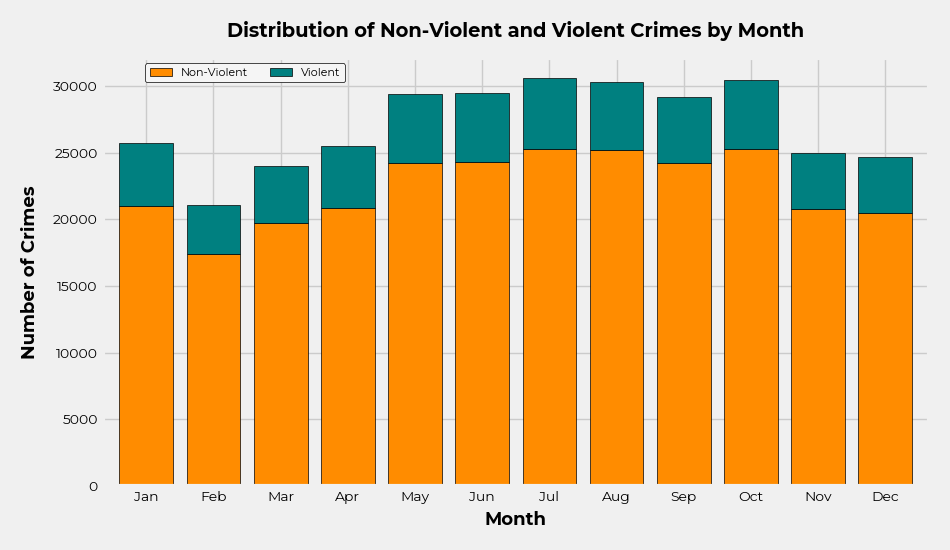

```python
# Data for Total column not needed.
pivoted = pivoted.drop('Total', axis = 1)

# Plot chart
ax = pivoted.plot(kind = 'bar', stacked = True, figsize = (9.5, 5.5), edgecolor = 'black', width = 0.8,
                  color = ['#ff8c00', '#008080'])

ax.set_title('Distribution of Non-Violent and Violent Crimes by Month', fontsize = 14, fontweight = 'bold', pad = 15)
ax.set_xlabel('Month', fontsize = 13, fontweight = 'bold', labelpad = 5)
ax.set_ylabel('Number of Crimes', fontsize = 13, fontweight = 'bold', labelpad = 10)

# Edit x-axis tick labels to display months horizontally
months = ['Jan', 'Feb', 'Mar', 'Apr', 'May', 'Jun', 'Jul', 'Aug', 'Sep', 'Oct', 'Nov', 'Dec']
plt.xticks(range(12), months, rotation = 0)

# Adjust label size
ax.tick_params(axis = 'x', labelsize = 10)
ax.tick_params(axis = 'y', labelsize = 10)

# Create legend for all lines
legend = ax.legend(fontsize = 8, frameon = True, edgecolor= 'black', bbox_to_anchor = (0.3, 1), ncol = 2)
legend.get_frame().set_linewidth(0.5)
legend.get_frame().set_facecolor('#F5F5F5')
legend.get_frame().set_alpha(1.0)

plt.tight_layout()
plt.show()
```

#### A heatmap of crime counts by month and crime type

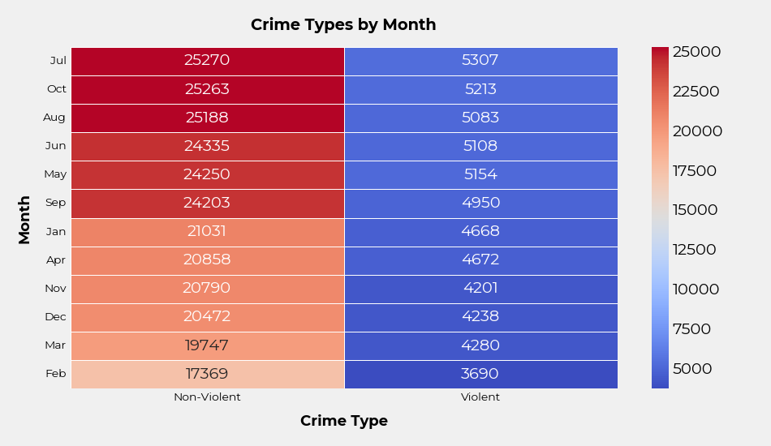

```python
# Pivot data for selected columns.  Rename numerical months to alpha
heatmap_df = pd.pivot_table(df1, values = 'CCN', columns = 'CRIMETYPE', aggfunc='count',
                            index = pd.to_datetime(df1['MONTH'], format = '%m').dt.strftime('%b'))

# Sort summed values for Non-Violent and Violent crimes
heatmap_df = heatmap_df.loc[heatmap_df[['Non-Violent', 'Violent']].sum(axis = 1).sort_values(ascending = False).index]

# Plot map
plt.figure(figsize = (9.5, 5.5))
sns.heatmap(heatmap_df, cmap = 'coolwarm', annot = True, fmt = 'g', linewidths = .5, cbar = True)

plt.title('Crime Types by Month', fontsize = 14, fontweight = 'bold', pad = 15)
plt.xlabel('Crime Type', fontsize = 13, fontweight = 'bold', labelpad = 10)
plt.ylabel('Month', fontsize = 13, fontweight = 'bold', labelpad = 10)

plt.xticks(fontsize = 10)
plt.yticks(fontsize = 10, rotation = 0)

plt.tight_layout()
plt.show()
```

#### Conclusive findings for Hypothesis 1 :

The crime trends tend to peak throughout May to October. However, it is interesting to note that there is an overall decrease in crime activity during the winter months of November and December which could potentially be attributed to the holiday season.

Therefore, the hypothesis that **violent** crimes are more likely to occur during certain months of the year compared to **non-violent** crimes is not supported by the data.

### Hypothesis 2

Neighborhoods with a higher population density will have a higher frequency of reported crimes.

#### A scatter plot of population density vs. frequency of reported crimes.

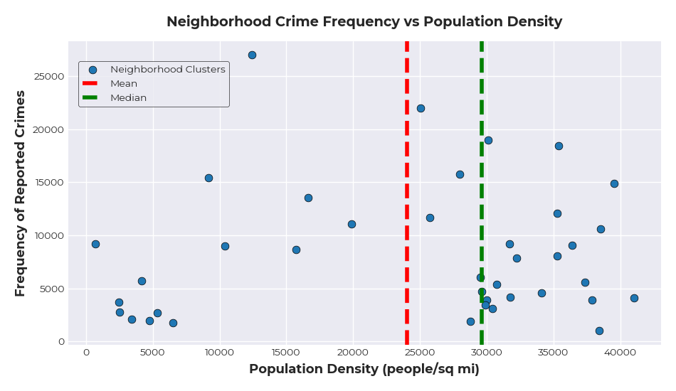

```python
# Set style parameters for Hypothesis 2 charts
plt.style.use('seaborn-v0_8-darkgrid')
plt.rcParams['font.family'] = 'montserrat'

# Make a df copy for Hypothesis 2
df2 = df.copy()

# Group data to calculate  population density and crime frequency.
crime_cluster = df2.groupby('NEIGHBORHOOD_CLUSTER').agg({'BLOCK_GROUP': 'count', 'CENSUS_TRACT': 'mean'}).reset_index()
crime_cluster.rename(columns = {'BLOCK_GROUP': 'CRIME_FREQUENCY'}, inplace = True)
crime_cluster['POPULATION_DENSITY'] = crime_cluster['CENSUS_TRACT'] / 0.25  # assuming 1/4 sq mile area

# Plot
fig, ax = plt.subplots(figsize = (9.5, 5.5))
ax.scatter(crime_cluster['POPULATION_DENSITY'], crime_cluster['CRIME_FREQUENCY'],
           color = '#1F77B4', label = 'Neighborhood Clusters', edgecolor = 'black', s = 60)

# Plot lines showing mean and median
mean_density = crime_cluster['POPULATION_DENSITY'].mean()
ax.axvline(x = mean_density, color = 'red', linestyle = '--', label = 'Mean')

median_density = crime_cluster['POPULATION_DENSITY'].median()
ax.axvline(x = median_density, color = 'green', linestyle = '--', label = 'Median')

ax.set_title('Neighborhood Crime Frequency vs Population Density', fontsize = 14, fontweight = 'bold', pad = 15)
ax.set_xlabel('Population Density (people/sq mi)', fontsize = 13, fontweight = 'bold', labelpad = 5)
ax.set_ylabel('Frequency of Reported Crimes', fontsize = 13, fontweight = 'bold', labelpad = 5)

plt.xticks(fontsize = 10)
plt.yticks(fontsize = 10)

legend = ax.legend(fontsize = 10, frameon = True, edgecolor = 'black', bbox_to_anchor = (0.28, 0.95))

plt.tight_layout()
plt.show()
```

#### A barplot showing the relationship between population density and frequency of reported crimes in different population density bins.

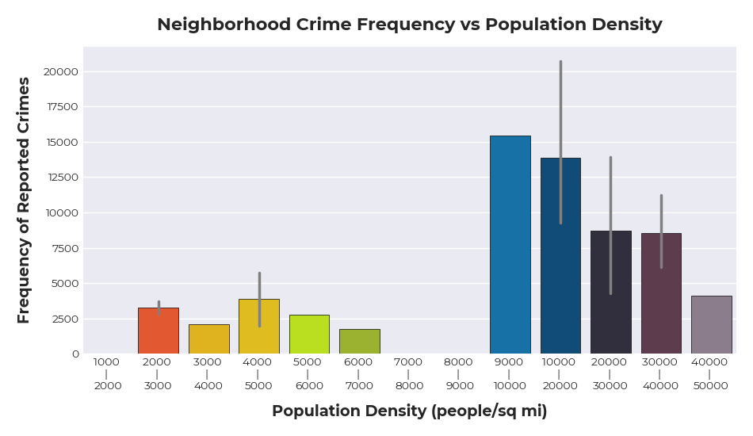

```python
# Define bins and labels
bins = [1000, 2000, 3000, 4000, 5000, 6000, 7000, 8000, 9000, 10000, 20000, 30000, 40000, 50000]
labels = ['1000 \n| \n2000', '2000 \n| \n3000', '3000 \n| \n4000', '4000 \n| \n5000', '5000 \n| \n6000',
          '6000 \n| \n7000', '7000 \n| \n8000', '8000 \n| \n9000', '9000 \n| \n10000', '10000 \n| \n20000',
          '20000 \n| \n30000', '30000 \n| \n40000', '40000 \n| \n50000']

# Cut population density into bins and add as new column
crime_cluster['POPULATION_DENSITY_BINNED'] = pd.cut(crime_cluster['POPULATION_DENSITY'], bins = bins,
                                                labels = labels)

# Define colors for population density bins
colors = ['#CC3300', '#FF4713', '#FFC300', '#FFD200', '#CCFF00', '#A8C81A', '#38B44E', '#29BB9C', '#0077BE',
          '#004E8A', '#2F2B3F', '#62374E', '#8E7A8F']

# Plot
fig, ax = plt.subplots(figsize = (9.5, 5.5))
sns.barplot(x = 'POPULATION_DENSITY_BINNED', y = 'CRIME_FREQUENCY', data = crime_cluster, ax = ax,
            palette = colors, edgecolor = 'black', errwidth = 2.5, errcolor = '#808080')

ax.set_title('Neighborhood Crime Frequency vs Population Density', fontsize = 16, fontweight = 'bold', pad = 15)
ax.set_xlabel('Population Density (people/sq mi)', fontsize = 14, fontweight = 'bold', labelpad = 10)
ax.set_ylabel('Frequency of Reported Crimes', fontsize = 14, fontweight = 'bold', labelpad = 10)

plt.xticks(rotation = 0, fontsize = 10)
plt.yticks(fontsize = 10)

plt.tight_layout()
plt.show()
```

#### A 2D kernel density estimate (KDE) plot showing the relationship between population density and crime frequency

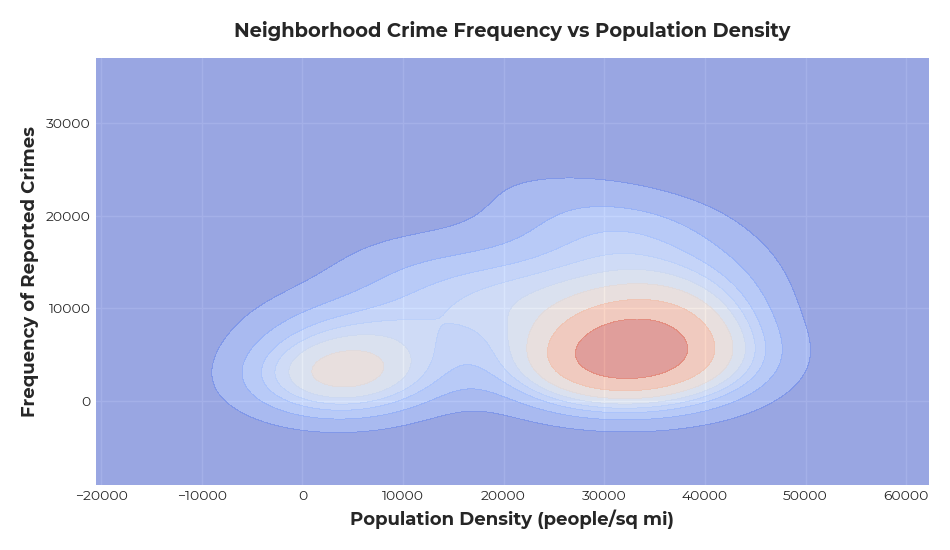

```python
# Plot
fig, ax = plt.subplots(figsize = (9.5, 5.5))
sns.kdeplot(x = 'POPULATION_DENSITY', y = 'CRIME_FREQUENCY', data = crime_cluster, fill = True,
            cmap = 'coolwarm', thresh = False, alpha = 0.5)

ax.set_title('Neighborhood Crime Frequency vs Population Density', fontsize = 14, fontweight = 'bold', pad = 15)
ax.set_xlabel('Population Density (people/sq mi)', fontsize = 13, fontweight = 'bold', labelpad = 5)
ax.set_ylabel('Frequency of Reported Crimes', fontsize = 13, fontweight = 'bold', labelpad = 5)

plt.xticks(fontsize = 10)
plt.yticks(fontsize = 10)

plt.tight_layout()
plt.show()
```

### Hypothesis 3

Crime rates in general tend to be higher during the evening and midnight shifts compared to the day shift. Furthermore, within the evening and midnight shifts, there may be a higher proportion of violent crimes compared to non-violent crimes.

**Sidenote :** Definition of types of shift in column SHIFT

MPD member's tour of duty associated with the time the report was taken. **DAY** shift generally runs between 0700 and 1500 (military time); **EVENING** shift between 1500 and 2300, and **MIDNIGHT** shift between 2300 and 0700.

#### A bar plot showing the total number of crimes by shift.

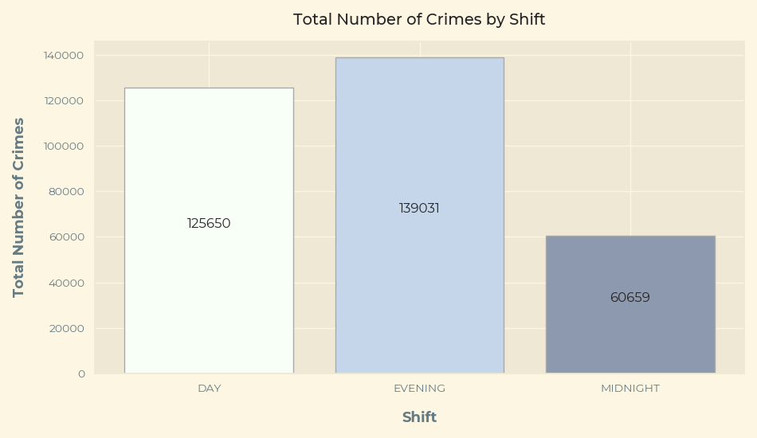

```python
# set style parameters for Hypothesis 3 charts
sns.set_theme(style = 'darkgrid', font_scale = 0.9)
plt.style.use('Solarize_Light2')
plt.rcParams['font.family'] = 'montserrat'

# make copy of df for Hypothesis 3
df3 = df.copy()

# count values for all shift types
day_total = len(df3[df3['SHIFT'] == 'DAY'])
evening_total = len(df3[df3['SHIFT'] == 'EVENING'])
midnight_total = len(df3[df3['SHIFT'] == 'MIDNIGHT'])

# set custom colors
colors = ['#F7FFF7', '#C5D5EA', '#8D99AE']

# Plot
fig, ax = plt.subplots(figsize = (9.5, 5.5))
plt.bar(['DAY', 'EVENING', 'MIDNIGHT'], [day_total, evening_total, midnight_total], color = colors,
        edgecolor = 'darkgray')

plt.title('Total Number of Crimes by Shift', fontsize = 14, fontweight = 'medium', pad = 15)
plt.xlabel('Shift', fontsize = 13, fontweight = 'bold', labelpad = 15)
plt.ylabel('Total Number of Crimes', fontsize = 13, fontweight = 'bold', labelpad = 15)

plt.xticks(fontsize = 10)
plt.yticks(fontsize = 10)

# add numerical labels inside the bars
for i, v in enumerate([day_total, evening_total, midnight_total]):
    plt.text(i, v/2, str(v), ha = 'center', va = 'bottom', fontsize = 12)

plt.tight_layout()
plt.show()
```

#### A scatter plot of Crime Type based on their location coordinates

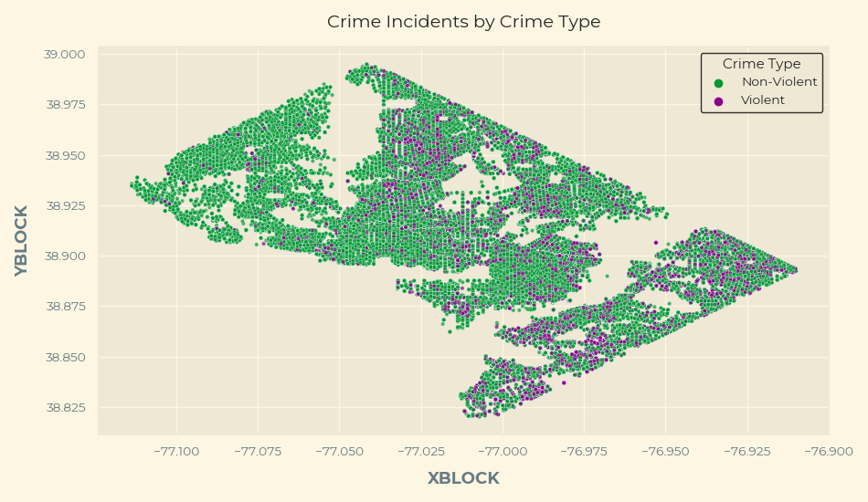

```python
# Define custom colors
custom_palette = sns.color_palette(['#009933', '#8B008B'])

# Plot
plt.figure(figsize = (9.5, 5.5))
sns.scatterplot(x = 'XBLOCK', y = 'YBLOCK', hue = 'CRIMETYPE', data = df3, s = 10, alpha = 0.7,
                palette = custom_palette)

plt.title('Crime Incidents by Crime Type', fontsize = 14, pad = 15)
plt.xlabel('XBLOCK', fontsize = 13, fontweight = 'bold', labelpad = 10)
plt.ylabel('YBLOCK', fontsize = 13, fontweight = 'bold', labelpad = 10)

# Set legend properties
ax = plt.gca()
ax.legend(title = 'Crime Type', fontsize = 10, frameon = True, edgecolor = 'black')

plt.tight_layout()
plt.show()
```

##### A boxplot showing distribution of the hour of day for two crime types across different shifts.

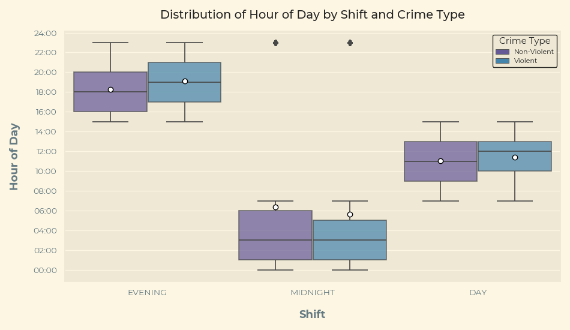

```python
# Plot
fig, ax = plt.subplots(figsize = (9.5, 5.5))
sns.boxplot(x = 'SHIFT', y = 'HOUR', hue = 'CRIMETYPE', data = df3, ax = ax,
            palette = ['#5E4FA2', '#3288BD', '#66C2A5'], boxprops = dict(alpha = .7), linewidth = 1.2,
            width = 0.9, showmeans = True, meanprops = dict(marker='o', markeredgecolor = 'black',
            markerfacecolor = 'white', markersize = 6))

ax.set_title('Distribution of Hour of Day by Shift and Crime Type', fontsize = 14, fontweight = 'medium', pad = 15)
ax.set_xlabel('Shift', fontsize = 13, fontweight = 'bold', labelpad = 15)
ax.set_ylabel('Hour of Day', fontsize = 13, fontweight = 'bold', labelpad = 15)

plt.xticks(fontsize = 10)

# Modify y-axis ticks
hours = list(range(0, 25, 2))
ax.set_yticks(hours)
ax.set_yticklabels([f'{h:02d}:00' for h in hours], fontsize = 10)

ax.legend(title = 'Crime Type', bbox_to_anchor = (1, 1), fontsize = 8, frameon = True, edgecolor = 'black')

plt.tight_layout()
plt.show()
```

#### A scatter plot of hourly crime counts by shift.

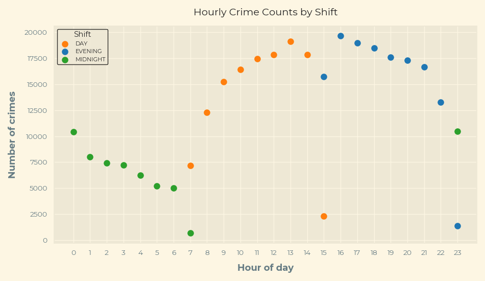

```python
# Group data by hour and shift.  Calculate the total number of crimes
hr_crime_counts = df3.groupby(['HOUR', 'SHIFT']).size().reset_index(name = 'COUNT')

# Extract values based on criteria for shift type against hour and count
day_hr = hr_crime_counts[hr_crime_counts['SHIFT'] == 'DAY']['HOUR']
day_count = hr_crime_counts[hr_crime_counts['SHIFT'] == 'DAY']['COUNT']

evening_hr= hr_crime_counts[hr_crime_counts['SHIFT'] == 'EVENING']['HOUR']
evening_count = hr_crime_counts[hr_crime_counts['SHIFT'] == 'EVENING']['COUNT']

midnight_hr = hr_crime_counts[hr_crime_counts['SHIFT'] == 'MIDNIGHT']['HOUR']
midnight_count = hr_crime_counts[hr_crime_counts['SHIFT'] == 'MIDNIGHT']['COUNT']

# Plot
fig, ax = plt.subplots(figsize = (9.5, 5.5))
ax.scatter(day_hr, day_count, color = '#FF7F0E', label = 'DAY', s = 65)
ax.scatter(evening_hr, evening_count, color = '#1F77B4', label = 'EVENING', s = 65)
ax.scatter(midnight_hr, midnight_count, color = '#2CA02C', label = 'MIDNIGHT', s = 65)

ax.set_title('Hourly Crime Counts by Shift', fontsize = 14, pad = 15)
ax.set_xlabel('Hour of day', fontsize = 13, fontweight = 'bold', labelpad = 10)
ax.set_ylabel('Number of crimes', fontsize = 13, fontweight = 'bold', labelpad = 10)

ax.set_xticks(range(0, 24, 1))
ax.set_xticklabels(range(0, 24, 1), fontsize = 10)
plt.yticks(fontsize = 10)

ax.legend(title = 'Shift', loc = 'upper left', fontsize = 8, frameon = True, edgecolor = 'black')

plt.tight_layout()
plt.show()
```

#### Overview of data for Offense types by Year

```python
# Group data.  Count number of offenses in each group
offense_df = df3.groupby(['OFFENSE', 'YEAR']).size().unstack(fill_value = 0)

# Add a total column
offense_df['TOTAL'] = offense_df.sum(axis = 1)

# Add a percentage column
offense_df['%'] = offense_df['TOTAL'].div(offense_df['TOTAL'].sum(axis = 0)).multiply(100).round(2)

# Add a total row
offense_df.loc['YEARLY TOTAL'] = offense_df.sum()

# Convert all columns except the last column to integers
offense_df.iloc[:, : -1] = offense_df.iloc[:, : -1].astype(int)

offense_df
```

| YEAR OFFENSE | 2008 | 2009 | 2010 | 2011 | 2012 | 2013 | 2014 | 2015 | 2016 | 2017 | TOTAL | % |
| --- | --- | --- | --- | --- | --- | --- | --- | --- | --- | --- | --- | --- |
| ARSON | 56 | 39 | 26 | 30 | 34 | 34 | 26 | 18 | 5 | 4 | 272 | 0.08 |
| ASSAULT W/DANGEROUS WEAPON | 2856 | 2025 | 1801 | 1753 | 2311 | 2340 | 2422 | 2309 | 2090 | 1437 | 21344 | 6.56 |
| BURGLARY | 3695 | 3275 | 3774 | 3568 | 3564 | 3315 | 3139 | 2492 | 2031 | 1216 | 30069 | 9.24 |
| HOMICIDE | 175 | 116 | 112 | 76 | 87 | 101 | 105 | 153 | 128 | 89 | 1142 | 0.35 |
| MOTOR VEHICLE THEFT | 5263 | 4172 | 3332 | 2978 | 2773 | 2604 | 3052 | 2826 | 2567 | 1901 | 31468 | 9.67 |
| ROBBERY | 4045 | 3007 | 2787 | 3110 | 4112 | 3893 | 3207 | 3264 | 2764 | 1651 | 31840 | 9.79 |
| SEX ABUSE | 134 | 109 | 126 | 138 | 252 | 289 | 307 | 324 | 323 | 236 | 2238 | 0.69 |
| THEFT F/AUTO | 0 | 3737 | 7653 | 9028 | 9635 | 10017 | 11167 | 11149 | 11735 | 8307 | 82428 | 25.34 |
| THEFT/OTHER | 17223 | 11815 | 8237 | 9062 | 11882 | 12662 | 14336 | 13931 | 13824 | 11567 | 124539 | 38.28 |
| YEARLY TOTAL | 33447 | 28295 | 27848 | 29743 | 34650 | 35255 | 37761 | 36466 | 35467 | 26408 | 325340 | 100.00 |

#### Classification of Offense by Crime Type : Violent and Non-Violent

```python
non = df3[df3['CRIMETYPE'] == 'Non-Violent']['OFFENSE'].unique()
vio = df3[df3['CRIMETYPE'] == 'Violent']['OFFENSE'].unique()

print()
print(f"Non-Violent crimes : {', '.join(non)}")
print()
print(f"Violent crimes : {', '.join(vio)}")
```

```
Non-Violent crimes : THEFT/OTHER, MOTOR VEHICLE THEFT, BURGLARY, THEFT F/AUTO, ARSON

Violent crimes : ROBBERY, ASSAULT W/DANGEROUS WEAPON, SEX ABUSE, HOMICIDE
```

##### A horizontal bar chart showing the frequency of different crime offenses in the dataset.

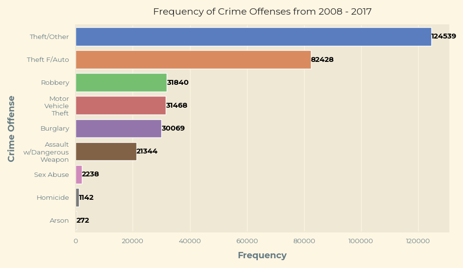

```python
# Plot
plt.figure(figsize = (9.5, 5.5))
sns.countplot(order = df3['OFFENSE'].value_counts().index, y = 'OFFENSE', data = df3, palette = 'muted')

plt.title('Frequency of Crime Offenses from 2008 - 2017', fontsize = 14, pad = 15)
plt.ylabel('Crime Offense', fontsize = 13, fontweight = 'bold', labelpad = 10)
plt.xlabel('Frequency', fontsize = 13, fontweight = 'bold', labelpad = 10)

plt.xticks(fontsize = 10)

# Edit y-axis labels
labels = ['Theft/Other', 'Theft F/Auto','Robbery','Motor\nVehicle\nTheft','Burglary',
          'Assault\nw/Dangerous\nWeapon','Sex Abuse','Homicide','Arson']
plt.yticks(range(len(labels)), labels, fontsize = 10)

# Adding OFFENSE values next to bar
for i, v in enumerate(df1['OFFENSE'].value_counts()):
    plt.text(v, i + 0.1, str(v), color = 'black', fontweight = 'bold')

plt.tight_layout()
plt.show()
```

#### A stacked bar chart showing the proportion of crimes by offense type and shift

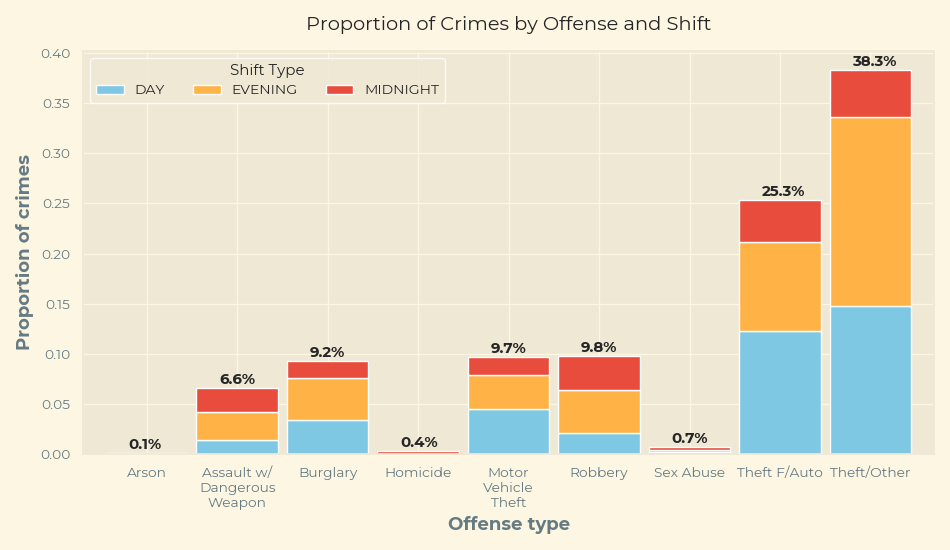

```python
# Group data.  Calculate proportions
shift_proportions = df3.groupby(['OFFENSE', 'SHIFT']).size().unstack() / len(df3)

# Fill missing value for columns
shift_proportions.fillna(0, inplace=True)

# Set custom colors
colors = ['#7EC8E3', '#FFB347', '#E74C3C']

# Plot
fig, ax = plt.subplots(figsize = (9.5, 5.5))
shift_proportions.plot(kind = 'bar', stacked = True, ax = ax, color = colors, width = 0.9)

ax.set_title('Proportion of Crimes by Offense and Shift', fontsize = 14, pad = 15)
ax.set_xlabel('Offense type', fontsize = 13, fontweight = 'bold')
ax.set_ylabel('Proportion of crimes', fontsize = 13, fontweight = 'bold')

# Edit text for xticks
labels = ['Arson', 'Assault w/\nDangerous\nWeapon', 'Burglary', 'Homicide', 'Motor\nVehicle\nTheft', 'Robbery',
          'Sex Abuse', 'Theft F/Auto','Theft/Other']

plt.xticks(range(len(labels)), labels)
plt.xticks(rotation = 0)

ax.legend(title = 'Shift Type', loc = 'upper left', fontsize = 10, frameon = True, edgecolor = 'white', ncol = 3)

# Add annotations to bars
for i, v in enumerate(shift_proportions.sum(axis = 1)):
    ax.text(i - 0.2, v + 0.004, '{:.1f}%'.format(v * 100), fontweight = 'bold')

plt.tight_layout()
plt.show()
```

#### A scatter plot of Type of Offenses based on their location coordinates

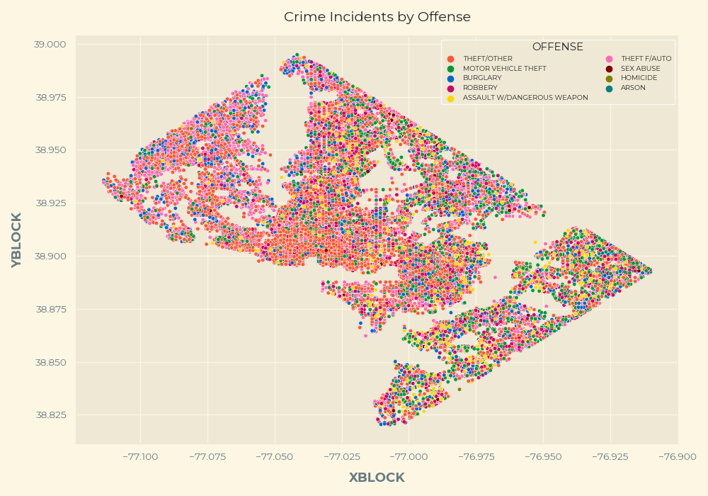

```python
# Set custom colors
custom_palette = sns.color_palette(['#FF5733', '#009933', '#0066cc', '#cc0066', '#ffd700', '#ff69b4', '#800000',
                                    '#808000', '#008080'])

# Plot
plt.figure(figsize = (10, 7))
sns.scatterplot(x = 'XBLOCK', y = 'YBLOCK', hue = 'OFFENSE', data = df3, s = 15, alpha = 1, palette = custom_palette)

plt.title('Crime Incidents by Offense', fontsize = 14, pad = 15)
plt.xlabel('XBLOCK', fontsize = 13, fontweight = 'bold', labelpad = 10)
plt.ylabel('YBLOCK', fontsize = 13, fontweight = 'bold', labelpad = 10)

# Set legend properties
ax = plt.gca()
ax.legend(title = 'OFFENSE', fontsize = 7, frameon = True, edgecolor = 'white', ncol = 2)

plt.tight_layout()
plt.show()
```

#### A stacked bar chart that shows the number of incidents for each offense type grouped by shift.

```python
# Group data and calculate values
by_shift = df3.groupby(['SHIFT', 'OFFENSE'])['CCN'].count().reset_index()

# Pivot df for selected data
by_shift_pivot = by_shift.pivot(index = 'SHIFT', columns = 'OFFENSE', values = 'CCN')

by_shift_pivot
```

| OFFENSE SHIFT | ARSON | ASSAULT W/DANGEROUS WEAPON | BURGLARY | HOMICIDE | MOTOR VEHICLE THEFT | ROBBERY | SEX ABUSE | THEFT F/AUTO | THEFT/OTHER |
| --- | --- | --- | --- | --- | --- | --- | --- | --- | --- |
| DAY | 80.0 | 4558.0 | 11108.0 | NaN | 14477.0 | 6842.0 | 637.0 | 39805.0 | 48143.0 |
| EVENING | 94.0 | 9006.0 | 13678.0 | NaN | 11137.0 | 13961.0 | 802.0 | 29070.0 | 61283.0 |
| MIDNIGHT | 98.0 | 7780.0 | 5283.0 | 1142.0 | 5854.0 | 11037.0 | 799.0 | 13553.0 | 15113.0 |

It is worth noting there aren't any values for a violent crime such as homicide, for both the day and evening shift.

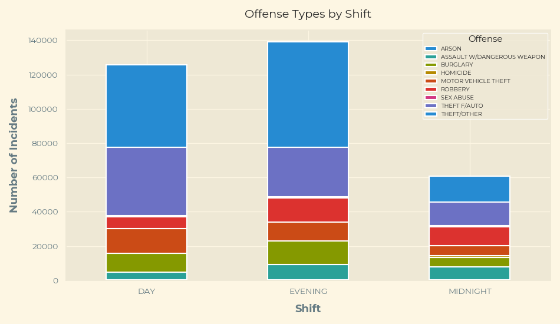

```python
# Fill missing values
by_shift_pivot['HOMICIDE'].fillna(0, inplace = True)

# Plot
ax = by_shift_pivot.plot(kind = 'bar', stacked = True, figsize = (9.5, 5.5), width = 0.5, linewidth = 1.5)

ax.set_title('Offense Types by Shift', fontsize = 14, pad = 15)
ax.set_xlabel('Shift', fontsize = 13, fontweight = 'bold', labelpad = 10)
ax.set_ylabel('Number of Incidents', fontsize = 13, fontweight = 'bold', labelpad = 10)

plt.xticks(rotation = 0)

ax.legend(loc = 'upper right', fontsize = 7, frameon = True, edgecolor = 'white', title = 'Offense', ncol = 1)

plt.tight_layout()
plt.show()
```

#### Conclusive findings for Hypothesis 3 :

The plotted data shows crime rates are generally higher during the evening and midnight shifts compared to the day shift. A **total** of 199,690 crimes occurred during the **evening** and **midnight shifts**, while 125,650 crimes occurred during the **day shift**.

Additionally, a higher proportion of crimes occurred during the evening and midnight shifts than during the day shift. This difference of proportions suggests that there are more crimes committed during hours of darkness.

Therefore, the findings support the hypothesis that crime rates are higher during the evening and midnight shifts, and that violent crimes may be more likely to occur during those shifts.

### Section 4 : Conclusion

The findings also supported Hypothesis 3 which stated that crime rates are generally higher during the evening and midnight shifts compared to the day shift, and that within the evening and midnight shifts, there may be a higher proportion of violent crimes compared to non-violent crimes.

However, Hypothesis 1, which stated there is a difference in the distribution of crime types between months, with violent crimes more likely to occur during certain months of the year compared to non-violent crimes, was not supported by the data.

These findings could have important implications for policymakers and law enforcement agencies in Washington DC, who could use this information to allocate resources and plan interventions to reduce crime in high-risk areas and during high-risk times.

Overall, this analysis provides a foundation for future research in this area and highlights the importance of data-driven decision making in addressing crime in urban areas.

### Appendix : Image Gallery

[figure not shown]

[link :](https://visual.ly/community/Infographics/geography/violent-crime-washington-dc)

### Selected Shootings from Jan to June 2008

[figure not shown]

[link :](https://blog.spotcrime.com/2008/06/shootings-in-washington-dc.html)

### 2020. Things just don't change

[figure not shown]

[link :](https://storymaps.arcgis.com/stories/0d222aace6fb475c8c9f1e02f147e5d0)

### Sodom & Gomorrah

[link :](https://www.city-data.com/crime/crime-Washington-District-of-Columbia.html)

FINITO!